# Model diagnostic

Xiaoyang Li

2019/12/8

# Model Diagnostic

## Functional form for continuous predictor

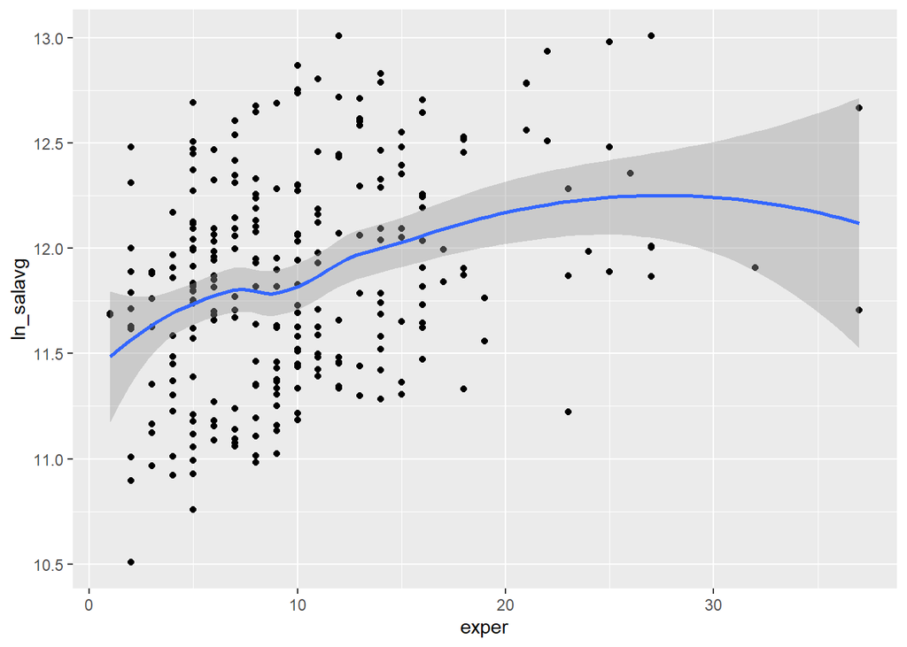

The only continuous variable is `exper`. So we made scatter plot for `exper` and `ln_salavg`. According to the scatter plot, we hypothesized there is non-linear relationship between `exper` and `ln_salavg`.

### Polynomial regression

For model 1 (interaction gender*exper)

We added its power 2, 3, 4 and its centering power 2, 3, 4 seperately to our model 1 to create polynomial models. But the summary result indicates that there is no association between higher order of `exper` and `ln_salavg`. Alao, by using anova, we fail to reject our reg13. There is no need to use high order model to improve our `reg13`.

For model 2 (interaction gender*rank)

We use the same process to test whether polynomial regression could improve our model containing interaction between gender and rank. There is no need to use higher order of exper, neither.

### Piecewise model

To make piecewise model, I choose exper = 7.5 and exper = 9 as knots according to the scatter plot.

For model 2, P-value of knot at exper = 9 is 0.001 which indicate coefficient of exper change significantly here. However, the adjusted R-square is far less than reg14. Therefore, our original model fits the data better.

## Diagnostic

### Multicollinearity

For model 1 (interaction gender*exper)

|  | x |
| --- | --- |
| gendermale | 1.207354 |
| dept2 | 1.894436 |
| dept3 | 1.775204 |
| dept4 | 2.748729 |
| dept5 | 3.930318 |
| dept6 | 3.038340 |
| clin1 | 1.983056 |
| cert1 | 1.396052 |
| rank2 | 1.103716 |
| rank3 | 1.148014 |

|  | x |
| --- | --- |
| gendermale | 1.301580 |
| dept2 | 1.419295 |
| dept3 | 1.298414 |
| dept4 | 1.400235 |
| dept5 | 2.129589 |
| dept6 | 2.058084 |
| clin1 | 1.563786 |
| cert1 | 1.346859 |
| rank2 | 2.616493 |
| rank3 | 2.728842 |

|  | x |
| --- | --- |
| gendermale | 1.453647 |
| dept2 | 1.689401 |
| dept3 | 1.286818 |
| dept5 | 2.417561 |
| dept6 | 2.590909 |
| clin1 | 2.145632 |
| cert1 | 1.199235 |
| rank3 | 1.258038 |

We tested VIF after stratification by experience and found there is no predictors’ vif larger than 5. So none of predictor’s coefficient might be misleading due to collinearity.

For model 2 (interaction gender*rank)

|  | x |
| --- | --- |
| gendermale | 1.388703 |
| dept2 | 1.788001 |
| dept3 | 1.646600 |
| dept4 | 2.506182 |
| dept5 | 3.759025 |
| dept6 | 3.218099 |
| clin1 | 1.822424 |
| cert1 | 1.387240 |

|  | x |
| --- | --- |
| gendermale | 1.192175 |
| dept2 | 1.494380 |
| dept3 | 1.325727 |
| dept4 | 2.125445 |
| dept5 | 2.805415 |
| dept6 | 2.316121 |
| clin1 | 2.111921 |
| cert1 | 1.413204 |

|  | x |
| --- | --- |
| gendermale | 1.211899 |
| dept2 | 1.502562 |
| dept3 | 1.436424 |
| dept4 | 1.235696 |
| dept5 | 1.900869 |
| dept6 | 1.897666 |
| clin1 | 1.661902 |
| cert1 | 1.284494 |

Also, we tested VIF after stratification by rank and found there is no predictors’ vif larger than 5. So none of predictor’s coefficient might be misleading due to collinearity.

### Assumptions

For model 1 (interaction gender*exper)

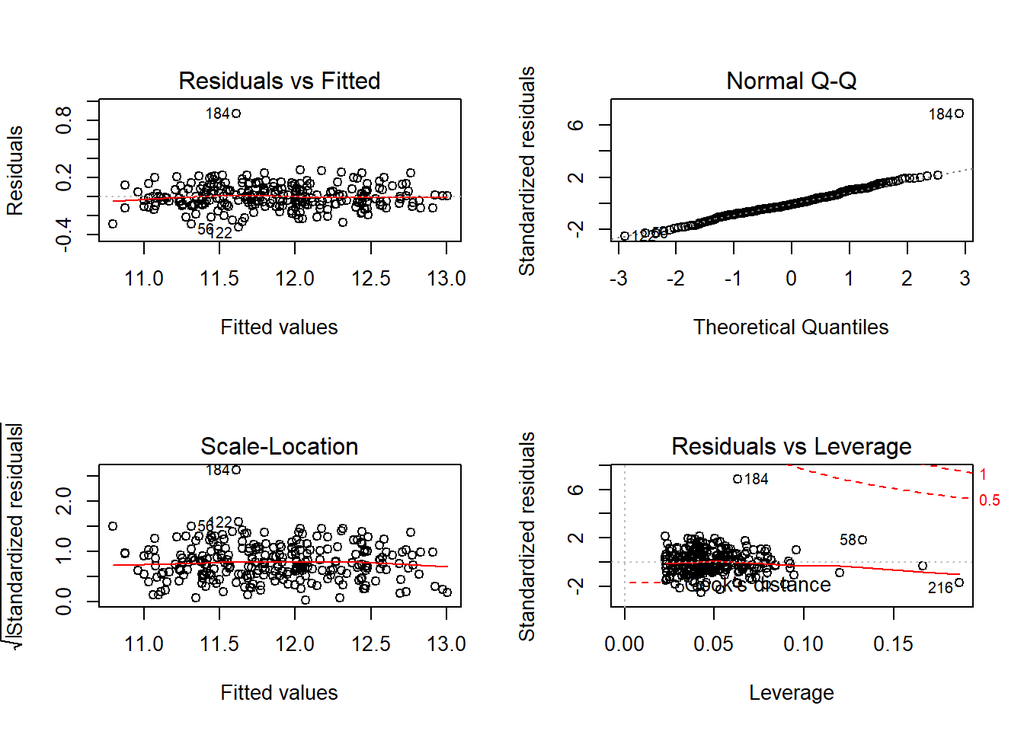

Based on the diagnostic plots for model 1, we can see the constant variance assumptions hold well. The curves in residuals vs fitted plot are horizontal and bounce around 0 which indicates that constant variance is satisfied in our model. Scale-location plot shows the same thing. No.184 observations deviates from the normal line on the qq plot means it might be a outlier. Except from this observation, other observations satisfy normality pretty well.

In addition, the same observation is close to the 0.5 cook’s distance in residuals vs leverage plot, which means No.184 observation might be influential.

For model 2 (interaction gender*rank)

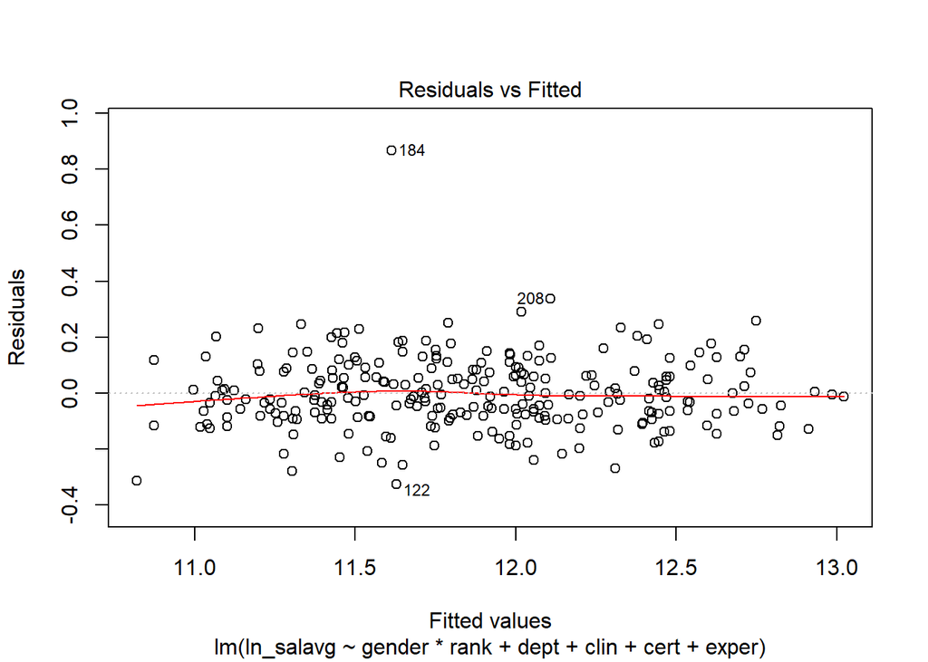

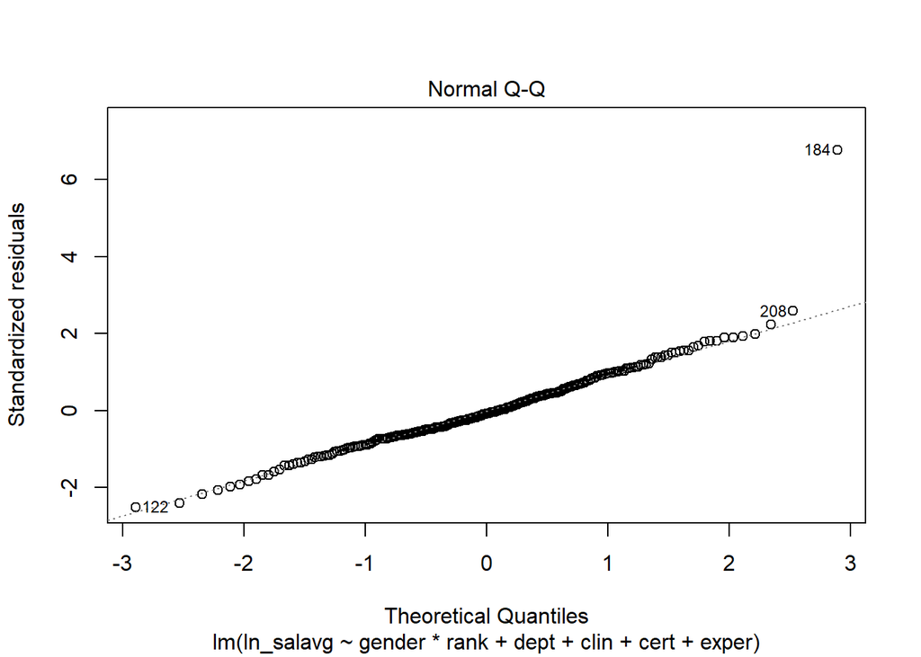

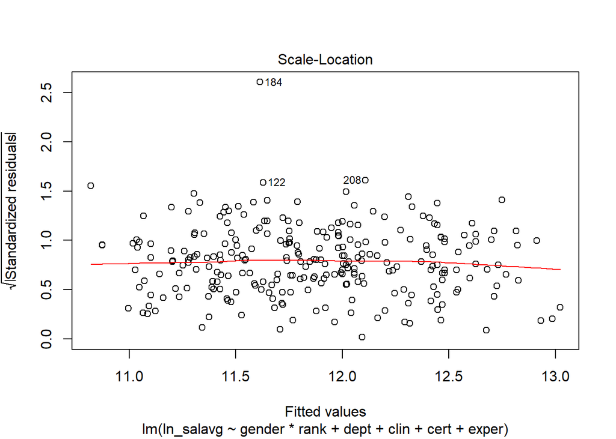

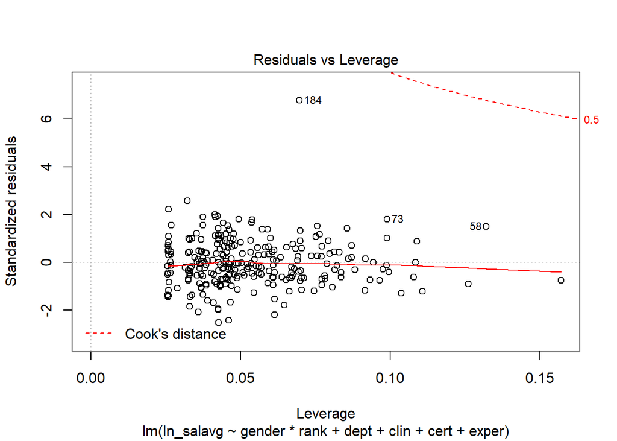

Diagnostic plots for model 2 show similar things, except from No.184 observation, other observations satisfy all of our assumptions very well. It might be influential point in the same time.

### Outlier and influential points

For model 1 (interaction gender*exper)

According to residuals vs fitted plot and scale-location plot, we can find that No.56, No.122, No. 184 observation are outliers. The No.184 obervation are far away from others.

After deleting no.184 observation, adjusted R-square improve from 0.9337 to 0.9458. In addition, several coefficient change. Specifically, coefficient of gender changes a lot (0.129 to 0.098).

Then we deleted other outliers(No. 56, No. 122), adjusted R-square improve didn’t improve very much. Coefficient of gender changes a lot (0.098 to 0.084).

To summary, outliers containning No.56, No.122 and No. 184 observation. They are influential points in the same time, which means there might be other potential preditor we didn’t take into consideration in our model 1.

According to influence mesure result, we found that No. 19, No. 44, No. 56, No. 58, No. 59, No. 88, No. 122, No. 125, No. 135, No. 172, No. 184, No. 216, No. 239 are potential influential points. Except from outliers we deleted above, we delete other potential influential points in `reg_i`.

After comparing summary results of `reg13_o_` and `reg13_i`, adjusted R-squared improve a little. Coefficients of all predictor don’t change largely. So none of our potential influential observation are really influential points after testing.

For model 2 (interaction gender*rank)

According to residuals vs fitted plot and scale-location plot, we can find that No. 122, No. 184, No.208 observation are outliers. The No.184 obervation are far away from others.

After deleting no.184 observation, adjusted R-square improve from 0.9322 to 0.9445. In addition, several coefficient change significantly. Specifically, coefficient of gender changes a lot (0.074 to 0.046).

Then we deleted other outliers(No. 122, No. 208), adjusted R-square improve didn’t improve very much. But, coefficient of gender changes a lot (0.046 to 0.090).

To summary, outliers containning No.122, No.184 and No. 208 observation. They are influential points in the same time, which means there might be other potential preditor we didn’t take into consideration in our model 2.

```r
influence.measures(reg14) # 19,44,56,58,59,88,125,135,172,216,239
```

[output not shown]

[output cut: 774 more lines]

According to influence mesure result, we found that No. 19, No. 44, No. 56, No. 58, No. 59, No. 88, No. 122, No. 125, No. 135, No. 172, No. 184, No. 216, No. 239 are potential influential points. Except from outliers we deleted above, we delete other potential influential points in `reg_i`.

After comparing summary results of `reg13_o_` and `reg13_i`, adjusted R-squared improve a little. Coefficients of all predictor don’t change largely. So none of our potential influential observation are really influential points after testing.